# Part II - Prosper Loan Data Exploration

## by Isaac Godwin

## Investigation Overview

For the presentation, my aims is to focus on the process of exploring the individual variable of interest to discover the relationship between the borrowers and the loan borrowed.

The variable of interest will be introduced, and then examine how they relate to each another and eventually how their correlation is affected by another variable. The variables include the following; Borrowers' employment status, their income range, stated monthly income and the loan original amount.

## Dataset Overview

The dataset used for this project is the Prosper loan Dataset, which was provided by Udacity. the data contains 113,937 observations with 81 variables.

For the purpose of these analysis, a subset dataset was created having only 16 variables of interest.

## Distribution of Employment status

To gain insights into the borrowers, the distribution of the borrower's employment status shows that the vast majority of the borrowers identify as employed and fultime.

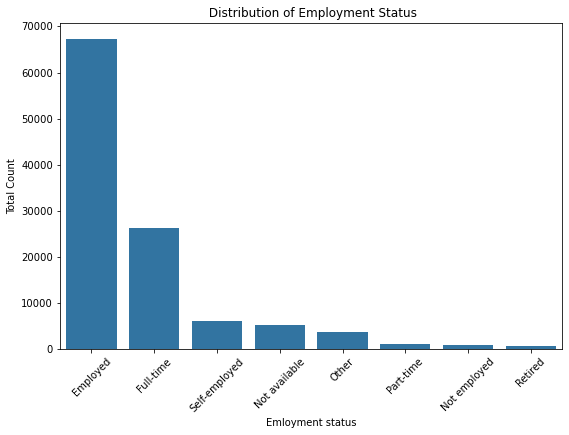

## Distribution of Income Range

The distribution indicated that Most of the borrowers have income between the range of ($)25,000-74,999.

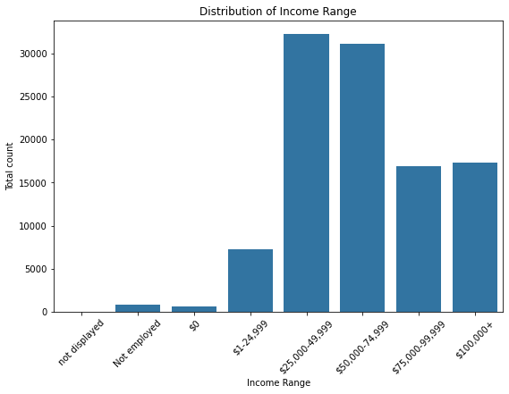

## Distribution of Stated Monthly Income

From the data displayed, it shows that the distribution of stated monthly income is right-skewed. in which most stated monthly income are less than 30k.

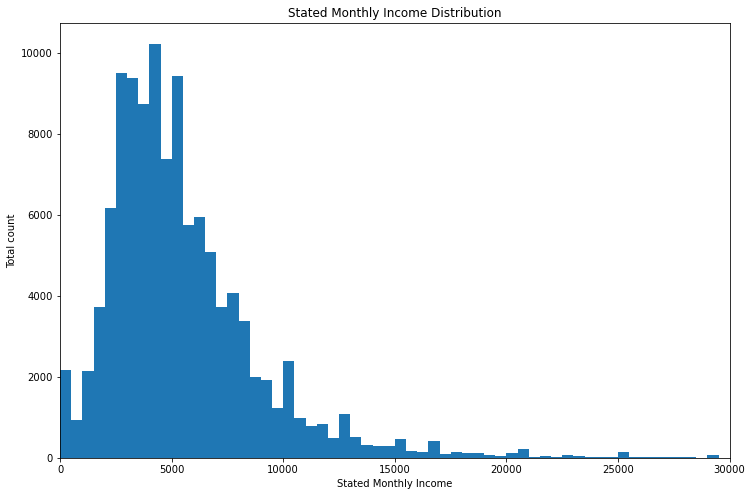

## Distribution of Borrower APR

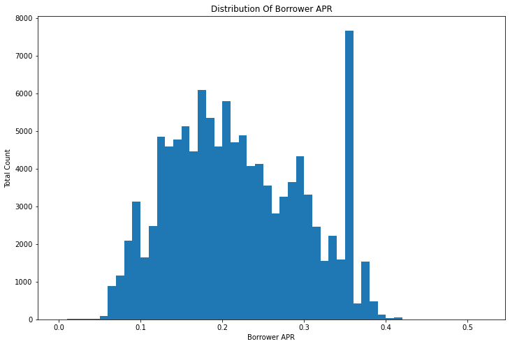

## Correlation Between Loan Original Amount, Stated Monthly Income, and Borrower Rate

From the heatmap it shows that Loan original amount and borrowers rate are nagatively correleted with a value of - 0.33 this indicated that the higer the borrower original amount the lowre the borrower rate on the loan. It also reveal that stated monthly income and loan original amount were positively correlated with a value point of 0.20 this indicated that the the higer the monthly income stated by the borrower the higher the loan gotten. However there is a low and nagative The correlation between stated monthly income and borrower rate with a value of -0.09.

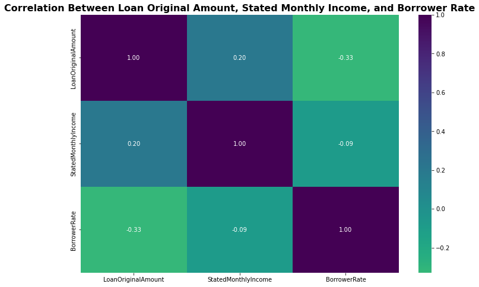

## Correlation between Borrower's Interest Rate and Loan Original Amount

Investigating further to see the correlation between borrower interest rate and their loan original amount, the chart shows that at different size of the loan amount, the BorrowerRate has a large range, but the range of BorrowerRate decrease with the increase of loan amount. That is, borrowers who borrowed higher loan amount had lesser interest rate

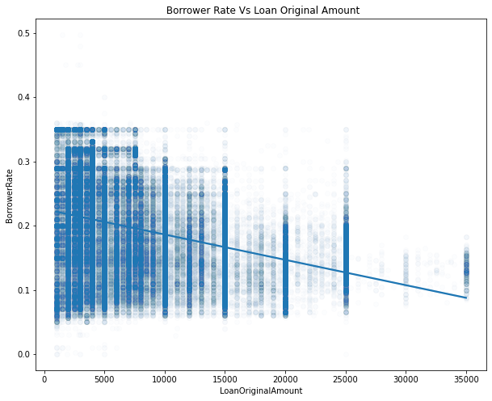

## Income Range vs Loan Amount by Verifiable Income

The data shows that those who earn 100,000+ and have verified their income tend to get larger loan original amount than those whose income are not verifiable. The borrowers with verified incomes tend to get higher loan amounts.

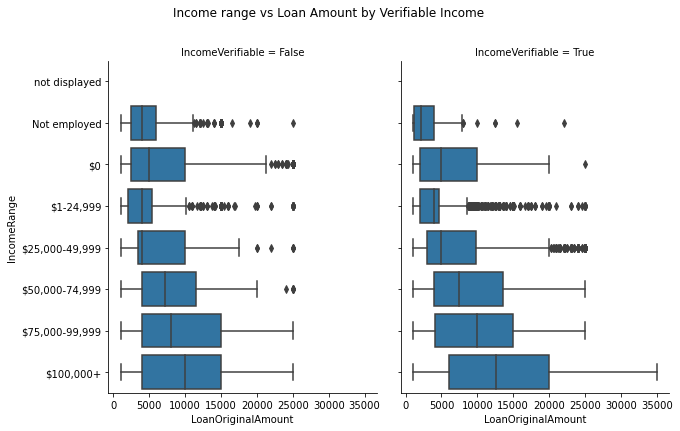